# spatial8

Meredith Franklin

10/24/2019

## Packages

Install any packages you might be missing:

```r
library(dplyr)
library(ggplot2)
library(leaflet)
library(sf) # handle simple features objects
library(units) # set_units() for converting units objects
library(spdep) # areal analysis
```

## Areal Data

North Carolina SIDS data

```r
nc<-st_read(system.file("shape/nc.shp", package = "sf"), stringsAsFactors = FALSE)
nc<-st_transform(nc,4326) # need to transform so that shapefile has WGS
nc
```

```
## Simple feature collection with 100 features and 14 fields
## geometry type:  MULTIPOLYGON
## dimension:      XY
## bbox:           xmin: -84.32385 ymin: 33.88199 xmax: -75.45698 ymax: 36.58965
## epsg (SRID):    4326
## proj4string:    +proj=longlat +datum=WGS84 +no_defs
## First 10 features:
##     AREA PERIMETER CNTY_ CNTY_ID        NAME  FIPS FIPSNO CRESS_ID BIR74
## 1  0.114     1.442  1825    1825        Ashe 37009  37009        5  1091
## 2  0.061     1.231  1827    1827   Alleghany 37005  37005        3   487
## 3  0.143     1.630  1828    1828       Surry 37171  37171       86  3188
## 4  0.070     2.968  1831    1831   Currituck 37053  37053       27   508
## 5  0.153     2.206  1832    1832 Northampton 37131  37131       66  1421
## 6  0.097     1.670  1833    1833    Hertford 37091  37091       46  1452
## 7  0.062     1.547  1834    1834      Camden 37029  37029       15   286
## 8  0.091     1.284  1835    1835       Gates 37073  37073       37   420
## 9  0.118     1.421  1836    1836      Warren 37185  37185       93   968
## 10 0.124     1.428  1837    1837      Stokes 37169  37169       85  1612
##    SID74 NWBIR74 BIR79 SID79 NWBIR79                       geometry
## 1      1      10  1364     0      19 MULTIPOLYGON (((-81.47276 3...
## 2      0      10   542     3      12 MULTIPOLYGON (((-81.23989 3...
## 3      5     208  3616     6     260 MULTIPOLYGON (((-80.45634 3...
## 4      1     123   830     2     145 MULTIPOLYGON (((-76.00897 3...
## 5      9    1066  1606     3    1197 MULTIPOLYGON (((-77.21767 3...
## 6      7     954  1838     5    1237 MULTIPOLYGON (((-76.74506 3...
## 7      0     115   350     2     139 MULTIPOLYGON (((-76.00897 3...
## 8      0     254   594     2     371 MULTIPOLYGON (((-76.56251 3...
## 9      4     748  1190     2     844 MULTIPOLYGON (((-78.30876 3...
## 10     1     160  2038     5     176 MULTIPOLYGON (((-80.02567 3...
```

```r
sids.pal = colorNumeric(c('blue','purple','pink','yellow'),
                       domain=nc$SID79/nc$BIR79)
nc %>%
  leaflet() %>%
  addProviderTiles('CartoDB.Positron') %>%
  addPolygons(fillColor=~sids.pal(SID79/BIR79), weight=.5, fillOpacity=.9,
              label=~paste0(NAME, ': ', BIR79)) %>%
  addLegend("bottomleft", pal = sids.pal, values = ~SID79/BIR79, title = "SIDS79 rate", opacity = 1)
```

[interactive chart not shown]

## Defining neighbours, weights

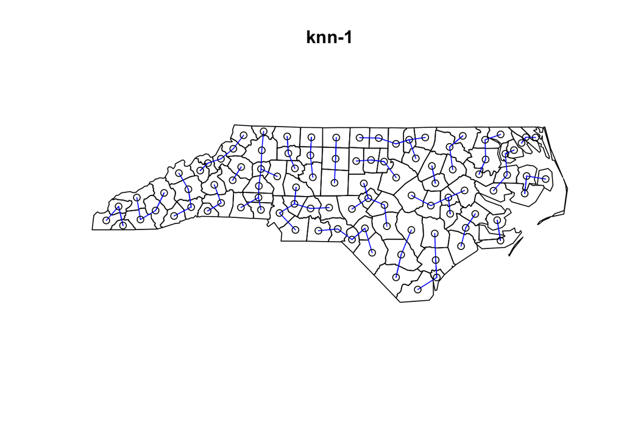

```r
# convert sf to spatial to use spdep
nc_sp <- sf:::as_Spatial(nc$geom)


# k nearest neighbours
# knearneigh() creates matrix with index for the regions belonging to knn
# knn2nb() creates neighbourhood list
sids_kn1<-knn2nb(knearneigh(coordinates(nc_sp), k=1, RANN=FALSE))
plot(nc_sp, main="knn-1")
plot(sids_kn1, coordinates(nc_sp),add=TRUE,col="blue")
```

```r
# create row standardized weights
sids_kn1_w<-nb2listw(sids_kn1, style="W")
sids_kn1_w
```

```
## Characteristics of weights list object:
## Neighbour list object:
## Number of regions: 100
## Number of nonzero links: 100
## Percentage nonzero weights: 1
## Average number of links: 1
## Non-symmetric neighbours list
##
## Weights style: W
## Weights constants summary:
##     n    nn  S0  S1  S2
## W 100 10000 100 152 480
```

```r
summary(unlist(sids_kn1_w$weights))
```

```
##    Min. 1st Qu.  Median    Mean 3rd Qu.    Max.
##       1       1       1       1       1       1
```

```r
# distance neighbours (still in degrees)
ndist<-unlist(nbdists(sids_kn1, coordinates(nc_sp)))
summary(ndist)
```

```
##    Min. 1st Qu.  Median    Mean 3rd Qu.    Max.
##  0.1197  0.2582  0.2964  0.2910  0.3239  0.4226
```

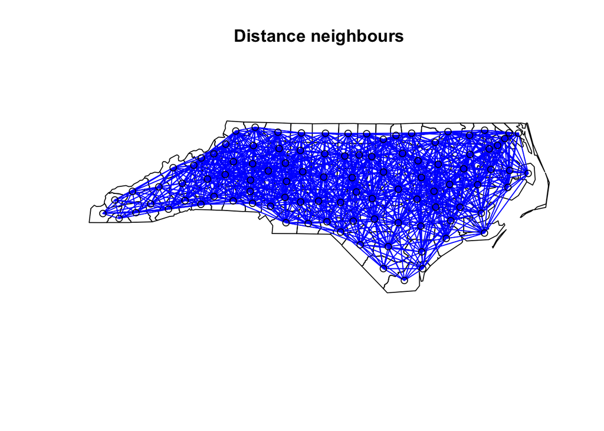

```r
max_dist_kn1<-max(ndist)
sids_dist1<-dnearneigh(coordinates(nc_sp), d1=0, d2=3*max_dist_kn1)
plot(nc_sp, main="Distance neighbours")
plot(sids_dist1, coordinates(nc_sp), add=T,col="blue")
```

```r
sids_dist1_w<-nb2listw(sids_dist1, style="W", zero.policy = TRUE)
summary(unlist(sids_dist1_w$weights))
```

```
##    Min. 1st Qu.  Median    Mean 3rd Qu.    Max.
## 0.03226 0.03448 0.03846 0.04425 0.04762 0.14286
```

## Global Moran’s I

- Compare the Moran’s I between local and regional weights matrices

```r
moranSIDS<-moran.test(nc$SID79/nc$BIR79,sids_kn1_w)
moranSIDS
```

```
##
##  Moran I test under randomisation
##
## data:  nc$SID79/nc$BIR79
## weights: sids_kn1_w
##
## Moran I statistic standard deviate = 2.5617, p-value = 0.005208
## alternative hypothesis: greater
## sample estimates:
## Moran I statistic       Expectation          Variance
##        0.30032839       -0.01010101        0.01468478
```

```r
moranSIDS2<-moran.test(nc$SID79/nc$BIR79,sids_dist1_w)
moranSIDS2
```

```
##
##  Moran I test under randomisation
##
## data:  nc$SID79/nc$BIR79
## weights: sids_dist1_w
##
## Moran I statistic standard deviate = -0.39183, p-value = 0.6524
## alternative hypothesis: greater
## sample estimates:
## Moran I statistic       Expectation          Variance
##     -0.0207675686     -0.0101010101      0.0007410604
```

```r
# Permutations, can save each randomization I and plot distribution
moranSIDS_mc<- moran.mc(nc$SID79/nc$BIR79,sids_kn1_w, nsim=999)
moranSIDS_mc$statistic
```

```
## statistic
## 0.3003284
```

```r
moranSIDS_mc$p.value
```

```
## [1] 0.006
```

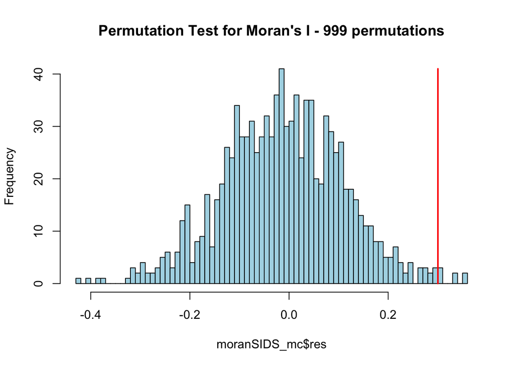

```r
# res are the 1000 simulations under randomization
distr999<- hist(moranSIDS_mc$res,freq=TRUE,col="light blue",main="Permutation Test for Moran's I - 999 permutations",breaks=75)
lines(moranSIDS_mc$statistic,max(distr999$counts),type="h",col="red",lwd=2)
```

- Determining at what lag structures we see significant spatial autocorrelation we generate correlogram plots to see what distance matrix produces significant Moran’s I
- The first correlogram type, using sp.correlogram() from the spdep library, takes a nb object, order, and method (“I” for Moran’s). It uses row standardized weights as a default and computes I under randomization. The plot is the spatial lags from the original nb object. For example, “queen” first order lag is the immediate neighbours; 2nd lag is the neighbours of neighbours; 3rd, etc.
- The second correlogram type, using correlog() from the pgirmess library, takes only the sp object and the number of neighbour classes. It computes all distances between areal units and classifies them into nbclass groups by breaking 0 to max dist into equal nbclass groups. If we want small distances we need to increase the number of distance bins (e.g. nbclass=30 vs nbclass=10).
- The second distance method not optimal for irregular areal units, better for grids

```r
sids_nb_queen<-poly2nb(nc_sp,queen=TRUE)
corrneigh<-sp.correlogram(sids_nb_queen, nc$SID79/nc$BIR79, order=15, method="I", style="S",zero.policy=TRUE)
corrneigh
```

```
## Spatial correlogram for nc$SID79/nc$BIR79
## method: Moran's I
##            estimate expectation   variance standard deviate
## 1 (100)   0.1260687  -0.0101010  0.0038745           2.1876
## 2 (100)  -0.0488951  -0.0101010  0.0021077          -0.8450
## 3 (100)  -0.1030788  -0.0101010  0.0016000          -2.3244
## 4 (100)  -0.0054517  -0.0101010  0.0015102           0.1196
## 5 (100)   0.0327605  -0.0101010  0.0016215           1.0644
## 6 (100)  -0.0172712  -0.0101010  0.0018811          -0.1653
## 7 (100)  -0.0804799  -0.0101010  0.0022140          -1.4957
## 8 (100)   0.0264079  -0.0101010  0.0024613           0.7359
## 9 (100)   0.0451651  -0.0101010  0.0028591           1.0336
## 10 (100) -0.0343182  -0.0101010  0.0037993          -0.3929
## 11 (95)  -0.0106010  -0.0106383  0.0044773           0.0006
## 12 (84)   0.0071796  -0.0120482  0.0052975           0.2642
```

[output cut: 21 more lines]

```r
print(corrneigh, p.adj.method = "bonferroni")
```

```
## Spatial correlogram for nc$SID79/nc$BIR79
## method: Moran's I
##            estimate expectation   variance standard deviate
## 1 (100)   0.1260687  -0.0101010  0.0038745           2.1876
## 2 (100)  -0.0488951  -0.0101010  0.0021077          -0.8450
## 3 (100)  -0.1030788  -0.0101010  0.0016000          -2.3244
## 4 (100)  -0.0054517  -0.0101010  0.0015102           0.1196
## 5 (100)   0.0327605  -0.0101010  0.0016215           1.0644
## 6 (100)  -0.0172712  -0.0101010  0.0018811          -0.1653
## 7 (100)  -0.0804799  -0.0101010  0.0022140          -1.4957
## 8 (100)   0.0264079  -0.0101010  0.0024613           0.7359
## 9 (100)   0.0451651  -0.0101010  0.0028591           1.0336
## 10 (100) -0.0343182  -0.0101010  0.0037993          -0.3929
## 11 (95)  -0.0106010  -0.0106383  0.0044773           0.0006
## 12 (84)   0.0071796  -0.0120482  0.0052975           0.2642
```

[output cut: 19 more lines]

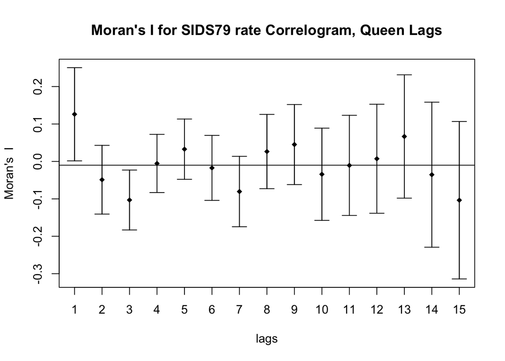

```r
plot(corrneigh,main="Moran's I for SIDS79 rate Correlogram, Queen Lags")
```

```r
sids_kn2<-knn2nb(knearneigh(coordinates(nc_sp), k=2, RANN=FALSE))
corrneigh2<-sp.correlogram(sids_kn2, nc$SID79/nc$BIR79, order=15, method="I", zero.policy=TRUE)
corrneigh2
```

```
## Spatial correlogram for nc$SID79/nc$BIR79
## method: Moran's I
##            estimate expectation    variance standard deviate
## 1 (100)  0.21468238 -0.01010101  0.00844201           2.4465
## 2 (93)  -0.05640304 -0.01086957  0.00747126          -0.5268
## 3 (97)  -0.13942341 -0.01041667  0.00605447          -1.6580
## 4 (97)   0.07391456 -0.01041667  0.00594924           1.0933
## 5 (97)   0.05155338 -0.01041667  0.00589239           0.8073
## 6 (97)  -0.06920203 -0.01041667  0.00611801          -0.7516
## 7 (97)  -0.10289958 -0.01041667  0.00630064          -1.1651
## 8 (97)  -0.23150636 -0.01041667  0.00649883          -2.7425
## 9 (97)   0.12027119 -0.01041667  0.00682779           1.5816
## 10 (97)  0.06105227 -0.01041667  0.00695822           0.8568
## 11 (94)  0.06733034 -0.01075269  0.00682026           0.9455
## 12 (89) -0.12675607 -0.01136364  0.00695422          -1.3837
```

[output cut: 21 more lines]

```r
print(corrneigh2, p.adj.method = "bonferroni")
```

```
## Spatial correlogram for nc$SID79/nc$BIR79
## method: Moran's I
##            estimate expectation    variance standard deviate
## 1 (100)  0.21468238 -0.01010101  0.00844201           2.4465
## 2 (93)  -0.05640304 -0.01086957  0.00747126          -0.5268
## 3 (97)  -0.13942341 -0.01041667  0.00605447          -1.6580
## 4 (97)   0.07391456 -0.01041667  0.00594924           1.0933
## 5 (97)   0.05155338 -0.01041667  0.00589239           0.8073
## 6 (97)  -0.06920203 -0.01041667  0.00611801          -0.7516
## 7 (97)  -0.10289958 -0.01041667  0.00630064          -1.1651
## 8 (97)  -0.23150636 -0.01041667  0.00649883          -2.7425
## 9 (97)   0.12027119 -0.01041667  0.00682779           1.5816
## 10 (97)  0.06105227 -0.01041667  0.00695822           0.8568
## 11 (94)  0.06733034 -0.01075269  0.00682026           0.9455
## 12 (89) -0.12675607 -0.01136364  0.00695422          -1.3837
```

[output cut: 21 more lines]

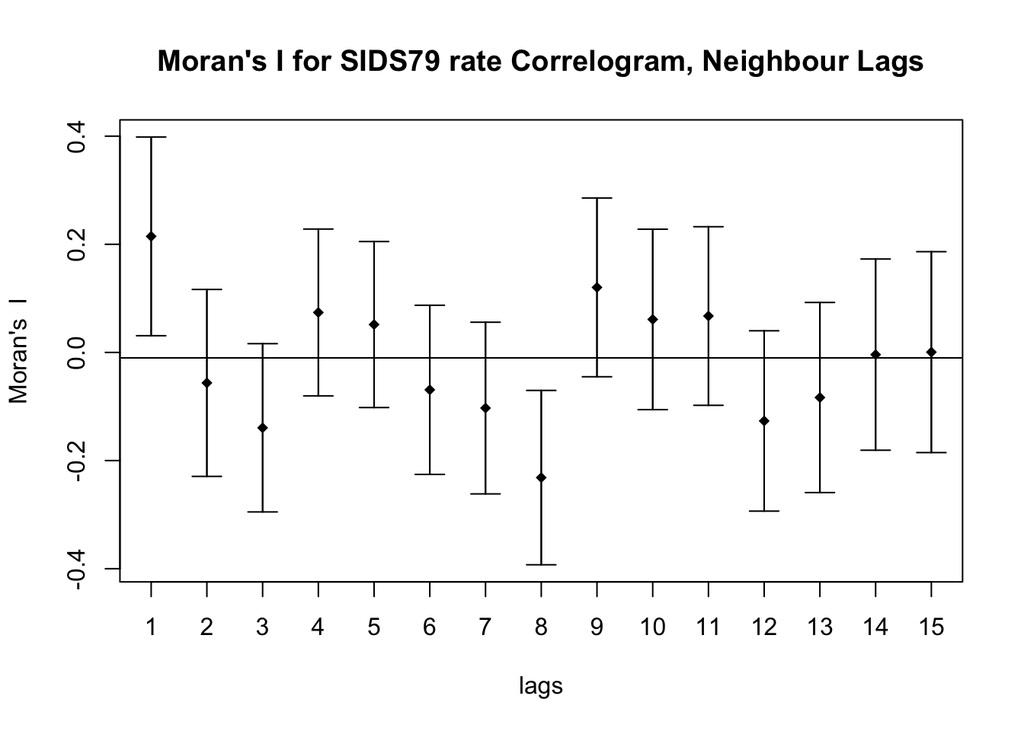

```r
plot(corrneigh2,main="Moran's I for SIDS79 rate Correlogram, Neighbour Lags")
```

```r
library(pgirmess)
corrdist.mi<-correlog(coordinates(nc_sp), nc$SID79/nc$BIR79, method="Moran", nbclass=30)
corrdist.mi
```

```
## Moran I statistic
##       dist.class         coef    p.value   n
##  [1,]  0.2547160  0.184341752 0.02187893 238
##  [2,]  0.5247002  0.042215576 0.21027205 504
##  [3,]  0.7946839 -0.093356812 0.92914937 660
##  [4,]  1.0646676 -0.098979192 0.94222902 692
##  [5,]  1.3346513 -0.010405470 0.50230140 752
##  [6,]  1.6046350  0.011972828 0.34359781 694
##  [7,]  1.8746187  0.007998087 0.37107064 666
##  [8,]  2.1446024  0.006745845 0.38508781 614
##  [9,]  2.4145860  0.080609479 0.05931860 582
## [10,]  2.6845697 -0.084155075 0.88205730 526
## [11,]  2.9545534 -0.083590397 0.88130840 510
## [12,]  3.2245371 -0.033208869 0.63827604 472
## [13,]  3.4945208  0.059649589 0.17288568 380
```

[output cut: 17 more lines]

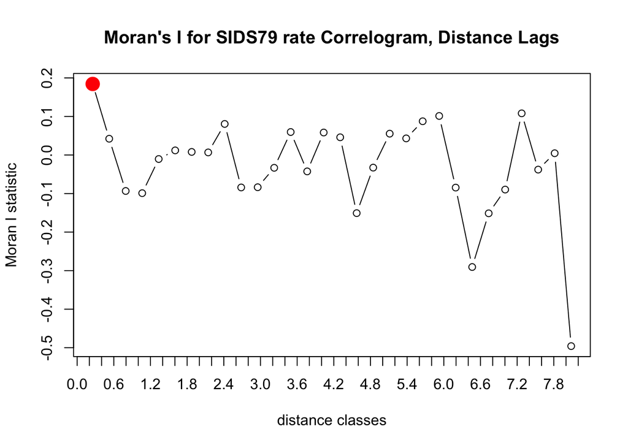

```r
plot(corrdist.mi,main="Moran's I for SIDS79 rate Correlogram, Distance Lags")
```

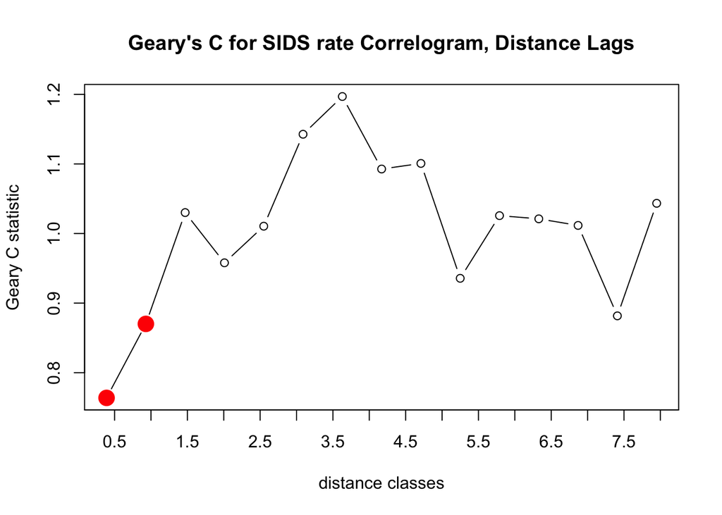

```r
# can also use Geary's c method for correlog
corrdist.gc<-correlog(coordinates(nc_sp),nc$SID74/nc$BIR74,method="Geary", nbclass=15)
plot(corrdist.gc,main="Geary's C for SIDS rate Correlogram, Distance Lags")
```

## Local Moran I

- Moving to local indexes of spatial autocorrelation we can first look at a Moran’s I scatterplot, which can pinpoint “outliers” by dividing the Moran’s I into quadrants
- We also directly compute the Local Moran’s I

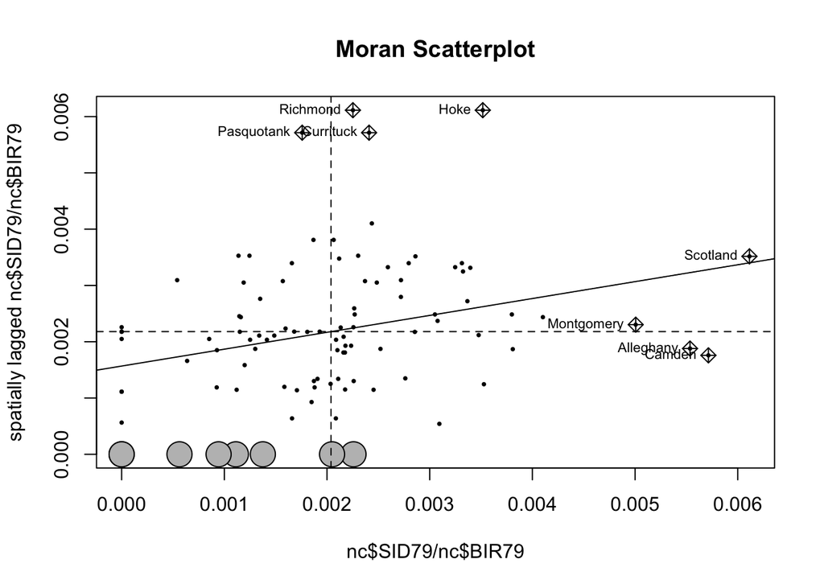

```
## Potentially influential observations of
##   lm(formula = wx ~ x) :
##
##            dfb.1_ dfb.x dffit   cov.r   cook.d hat
## Alleghany   0.24  -0.36 -0.38    1.10_*  0.07   0.09_*
## Currituck   0.07   0.09  0.31    0.87_*  0.04   0.01
## Camden      0.30  -0.43 -0.45_*  1.10_*  0.10   0.10_*
## Pasquotank  0.22  -0.07  0.32    0.85_*  0.05   0.01
## Montgomery  0.11  -0.17 -0.18    1.09_*  0.02   0.07_*
## Hoke       -0.17   0.38  0.48_*  0.87_*  0.11   0.03
## Richmond    0.12   0.06  0.34    0.83_*  0.05   0.01
## Scotland   -0.03   0.04  0.04    1.17_*  0.00   0.12_*
```

```r
mscat<-moran.plot(nc$SID79/nc$BIR79,sids_kn1_w, zero.policy=T, pch=16, col="black",cex=.5, quiet=F, labels=as.character(nc$NAME), main="Moran Scatterplot")
```

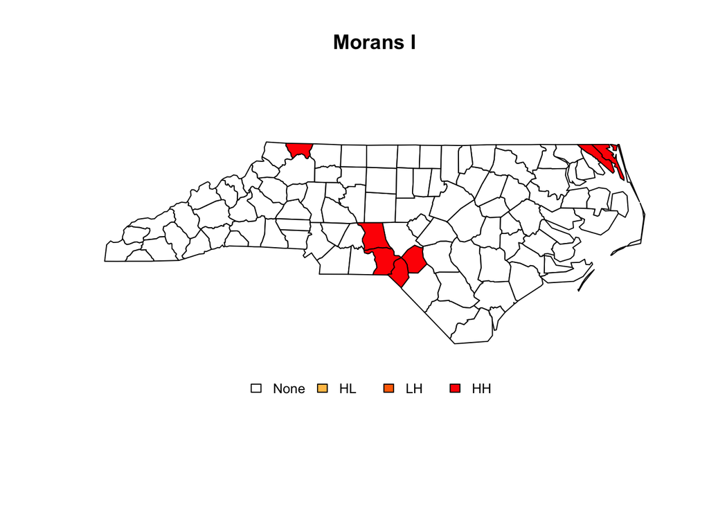

```r
# Plot counties that are in different quadrants of High-Low SIDS and Low-High SIDS
infl<- apply(mscat$is.inf, 1, any)

# Make break points for sids rates and lagged sids rates

# Break rates into low and high
sids79_LH_breaks <- cut(nc$SID79/nc$BIR79, breaks=c(min(nc$SID79/nc$BIR79), mean(nc$SID79/nc$BIR79), max(nc$SID79/nc$BIR79)), labels=c("L", "H"), include.lowest=TRUE)

sids_lag <- lag.listw(sids_kn1_w, nc$SID79/nc$BIR79)

# Break lagged rates into low and high
sids74_lag_breaks <- cut(sids_lag, breaks=c(min(sids_lag), mean(sids_lag), max(sids_lag)), labels=c("L", "H"), include.lowest=TRUE)
# Make quadrants LL,LH,HL,HH
lhlh <- interaction(sids79_LH_breaks, sids79_LH_breaks, infl, drop=TRUE)
# Identify low-low, low-high, etc colours
cols <- rep(1, length(lhlh))
cols[lhlh == "H.L.TRUE"] <- 2
cols[lhlh == "L.H.TRUE"] <- 3
cols[lhlh == "H.H.TRUE"] <- 4

col.palette <- colorRampPalette(c("white","orange", "red"), space = "rgb")
plot(nc_sp, col=col.palette(4)[cols], main="Morans I")
legend("bottom",horiz=TRUE , legend=c("None", "HL", "LH", "HH"), fill= col.palette(4), bty="n", cex=0.8, y.intersp=0.8)
```

```r
# Local Moran's I (similar for local Geary's c)

moranLocSIDS<-localmoran(nc$SID79/nc$BIR79,sids_kn1_w, p.adjust.method="bonferroni")
summary(moranLocSIDS)
```

```
##        Ii                E.Ii             Var.Ii            Z.Ii
##  Min.   :-1.08736   Min.   :-0.0101   Min.   :0.9651   Min.   :-1.09656
##  1st Qu.:-0.06570   1st Qu.:-0.0101   1st Qu.:0.9651   1st Qu.:-0.05659
##  Median : 0.04807   Median :-0.0101   Median :0.9651   Median : 0.05922
##  Mean   : 0.30033   Mean   :-0.0101   Mean   :0.9651   Mean   : 0.31599
##  3rd Qu.: 0.54004   3rd Qu.:-0.0101   3rd Qu.:0.9651   3rd Qu.: 0.56000
##  Max.   : 4.14340   Max.   :-0.0101   Max.   :0.9651   Max.   : 4.22792
##    Pr(z > 0)
##  Min.   :0.0000236
##  1st Qu.:0.5754808
##  Median :0.9527861
##  Mean   :0.7718062
##  3rd Qu.:1.0000000
##  Max.   :1.0000000
```

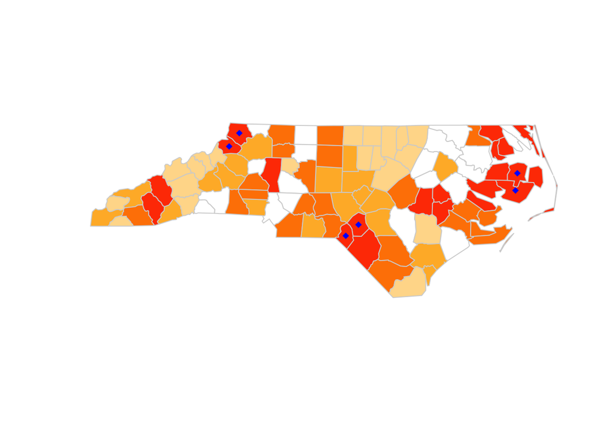

```r
moranLocSIDS2<-localmoran(nc$SID79/nc$BIR79,sids_dist1_w, p.adjust.method="bonferroni")


# plotting the results
# Looking at the z-scores

nc_sp$locM<-(moranLocSIDS[,1])
morans_breaks <- quantile(nc_sp$locM,seq(0,1,1/5))
col_ramp <-col.palette(length(morans_breaks))

# Statistically significant local Moran I as points
LocMoranTest = moranLocSIDS[,5]<=0.05

plot(nc_sp,border="lightgray",col=col_ramp[findInterval(moranLocSIDS[,1],morans_breaks,all.inside=TRUE)])
points(coordinates(nc_sp)[,1][LocMoranTest],coordinates(nc_sp)[,2][LocMoranTest], col="blue", cex=1, pch=18)
```

## Getis-Ord G*

- There is a global version of the Getis-Ord G* statistic, obtained using globalG.test()
- The local version uses localG(), which returns an object containing the Z-scores for the local G* statistic. The interpretation of the z-score is straightforward: a large positive value suggests a cluster of high SIDS rate (hot spot) and a large negative value indicates a cluster of low SIDS rates (cold spot).
- G* local uses binary weights recall that the Getis-Ord G statistic differs from Moran’s I or Geary C in that it makes a difference between high-high correlation and low-low correlation (both of which Moran’s I treats as positive autocorrelation)

```r
#global
sids_kn1_b<-nb2listw(sids_kn1, style="B")
getisSIDS<-globalG.test(nc$SID79/nc$BIR79,sids_kn1_b)
getisSIDS
```

```
##
##  Getis-Ord global G statistic
##
## data:  nc$SID79/nc$BIR79
## weights: sids_kn1_b
##
## standard deviate = 2.6216, p-value = 0.004376
## alternative hypothesis: greater
## sample estimates:
## Global G statistic        Expectation           Variance
##       1.190256e-02       1.010101e-02       4.722404e-07
```

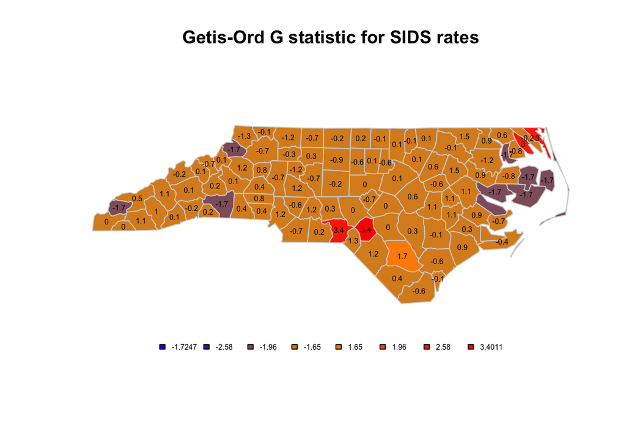

```r
# local

sids_kn1_b<-nb2listw(sids_kn1, style="B")
nc_sp$GstarSIDS<-localG(nc$SID79/nc$BIR79,sids_kn1_b,return_internals=TRUE)

# Graphing the G-stat
col.palette <- colorRampPalette(c("blue","orange", "red"), space = "rgb")
gstar_breaks <- c(min(nc_sp$GstarSIDS), -2.58, -1.96, -1.65, 1.65, 1.96, 2.58, max(nc_sp$GstarSIDS))
col_ramp <-col.palette(length(gstar_breaks))

# picks colors corresponding for each interval
plot(nc_sp,border="lightgray",col=col_ramp[findInterval(nc_sp$GstarSIDS,sort(gstar_breaks))])

# maps the shape file and fills each polygon with a color corresponding to the level of G at that location
text(coordinates(nc_sp)[,1],coordinates(nc_sp)[,2], round(nc_sp$GstarSIDS, digits=1), cex=0.5)
# writes the G-statistic in each polygon
legend("bottom",horiz=TRUE,legend=(round(gstar_breaks,digits=4)),fill=col_ramp,bty='n',cex=0.5)
title("Getis-Ord G statistic for SIDS rates")
```